# Analysis of frass data and frass methodology at UNC

========================================================================================================================

These data are being collected as part of the citizen science project *Caterpillars Count!* based in the Hurlbert lab at the University of North Carolina.

This project is testing frass trap prototypes using repurposed milk jugs, with a broader goal to create a streamlined and accessible frass collection method for citizen scientists. Currently, the data are being analysized to evaluate the reliability of this collection method, and of image-based estimates for frass weight.

**Repository location**: https://github.com/hurlbertlab/frass **Image processing package**: https://fiji.sc/

Here’s a plot comparing the weight of the “raw” frass collection (i.e. debris included) vs. the “sorted” frass (in which trained assistants have removed all non-frass pieces). All plots have been normalized for outliers in the data.

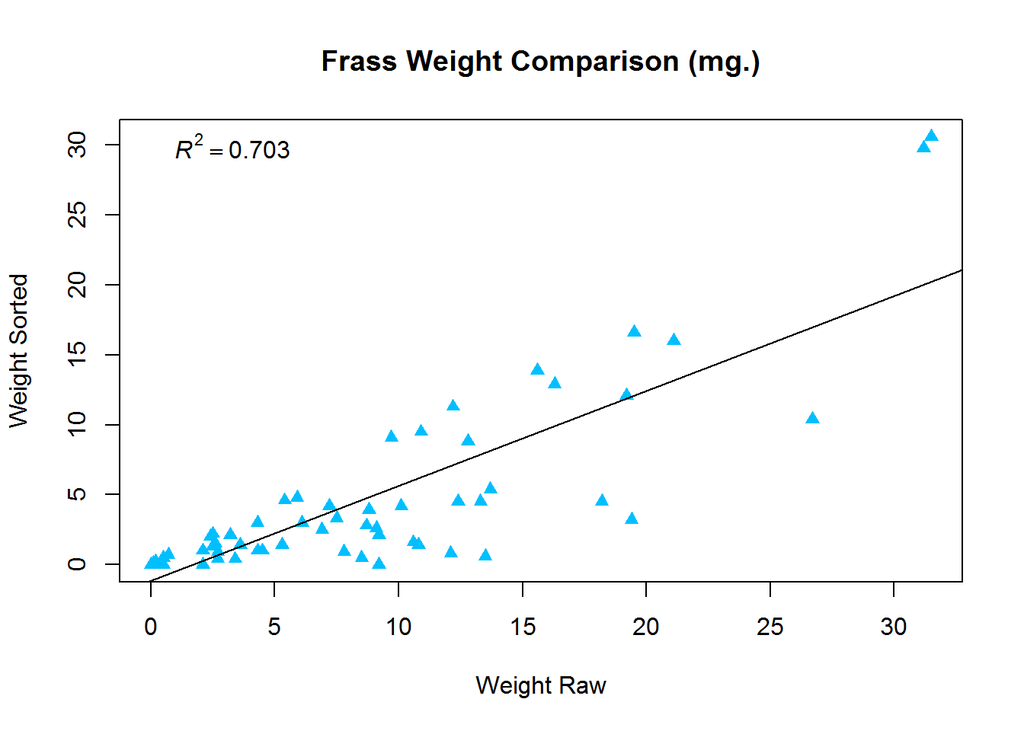

And here is the relationship between the raw frass pieces collected and the percent of area the raw frass pieces occupy using a standard backdrop, estimated by the image processer, Fiji.

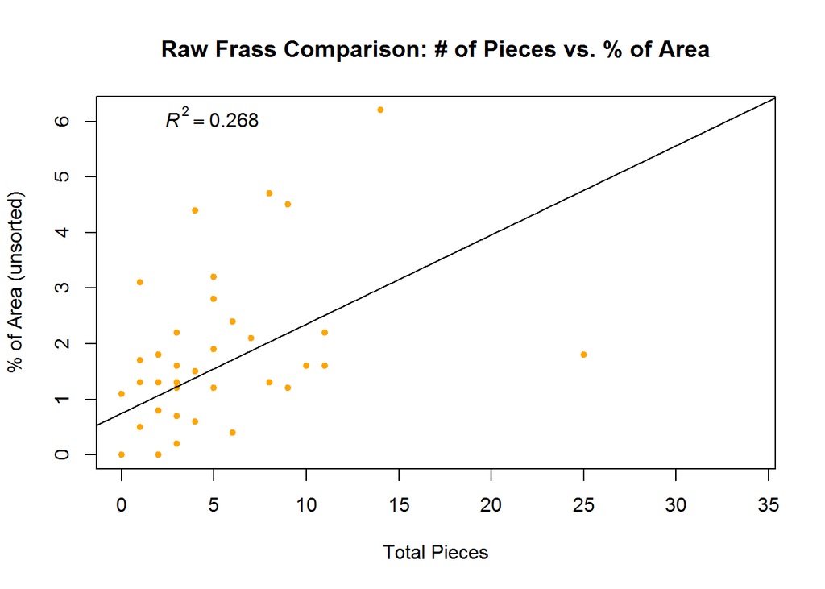

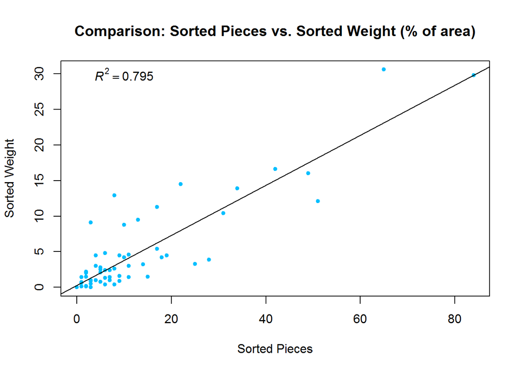

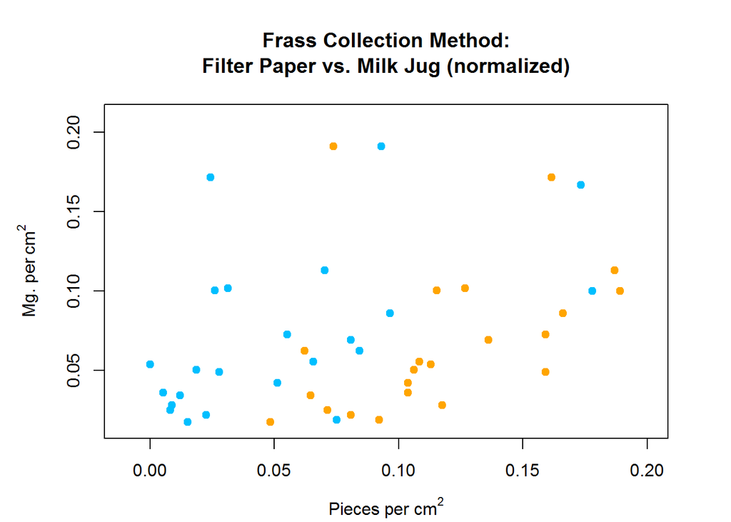